# Aboriginal Australia 1900-1909

Matti Munk Nielsen

`10 May 2024`

```r
knitr::opts_chunk$set(echo = TRUE,
                      message=FALSE)
```

# Download

## Library

```r
library(tidyverse)
library(tidytext)
library(ggwordcloud)
```

## Read the csv.file

```r
Aboriginal_1900_1909 <- read_csv("Aboriginal_Australia_1900-1909.csv")
```

## Show csv.file

```r
Aboriginal_1900_1909
```

```
## # A tibble: 100 × 15
##    article_text     article_id article_URL article_heading category article_date
##    <chr>                 <dbl> <chr>       <chr>           <chr>    <date>
##  1 "Aboriginal  Tr…  107196484 https://ap… Aboriginal Tra… Article  1906-11-09
##  2 "ABO&HHNAL  NAM…  113870079 https://ap… ABORIGINAL NAM… Article  1902-01-11
##  3 "ABORIGINAL  SK…  147643662 https://ap… ABORIGINAL SKE… Article  1907-08-12
##  4 "ABORIGINAL  LA…   14871478 https://ap… ABORIGINAL LAB… Article  1908-01-07
##  5 "Aboriginal  Pr…   19449847 https://ap… Aboriginal Pro… Article  1906-05-15
##  6 "ABORIGINAL  CR…  200951013 https://ap… ABORIGINAL CRI… Article  1907-03-29
##  7 "Aboriginal  De…  217889261 https://ap… Aboriginal Dep… Article  1904-10-14
##  8 "ABORIGINAL  MU…  262339445 https://ap… ABORIGINAL MUR… Article  1900-07-28
##  9 "ABORIGINAL  CA…    4893684 https://ap… ABORIGINAL CAN… Article  1902-04-29
## 10 "Aboriginal  Na…   61397565 https://ap… Aboriginal Nav… Article  1903-10-03
## # ℹ 90 more rows
## # ℹ 9 more variables: article_page <dbl>, article_page_sequence <chr>,
## #   article_snippet <chr>, article_Trove_URL <chr>, article_edition <chr>,
## #   article_title_id <dbl>, article_title_title <chr>,
## #   article_relevance_score <dbl>, article_relevance_value <chr>
```

# Textmining

## Unnest tokens

Unnest tokens separates individual words from the articles in a column.

```r
Aboriginal_1900_1909_tokens <-Aboriginal_1900_1909 %>%
  unnest_tokens(word,article_text)
```

## Count words

```r
Aboriginal_1900_1909_wc <- Aboriginal_1900_1909_tokens%>%
  count(word)%>%
  arrange(-n)
```

## Stopwordslist

A stopwordslist is a list of all the stopwords in all the 100 articles.

```r
Aboriginal_1900_1909_wc
```

```
## # A tibble: 6,688 × 2
##    word      n
##    <chr> <int>
##  1 the    1931
##  2 of      935
##  3 and     782
##  4 to      677
##  5 a       643
##  6 in      520
##  7 was     318
##  8 that    305
##  9 is      264
## 10 with    212
## # ℹ 6,678 more rows
```

## Remove stopwordslist

```r
Aboriginal_1900_1909_stop <- Aboriginal_1900_1909_tokens%>%
  anti_join(stop_words)
```

## Count words again

```r
Aboriginal_1900_1909_swc <- Aboriginal_1900_1909_stop%>%
  count(word)%>%
  arrange(-n)
```

## Show Aboriginal 1900 to 1909 swc head

```r
 Aboriginal_1900_1909_swc%>%
  head(10)
```

```
## # A tibble: 10 × 2
##    word            n
##    <chr>       <int>
##  1 aboriginal    185
##  2 tho            79
##  3 aboriginals    47
##  4 black          44
##  5 blacks         40
##  6 white          37
##  7 time           36
##  8 1              34
##  9 aborigines     34
## 10 found          33
```

## Remove nontext

```r
Aboriginal_1900_1909_no_numeric <- Aboriginal_1900_1909_stop%>%
  filter(is.na(as.numeric(word)))
```

## View nontext

```r
Aboriginal_1900_1909_no_numeric
```

```
## # A tibble: 12,126 × 15
##    article_id article_URL     article_heading category article_date article_page
##         <dbl> <chr>           <chr>           <chr>    <date>              <dbl>
##  1  107196484 https://api.tr… Aboriginal Tra… Article  1906-11-09              3
##  2  107196484 https://api.tr… Aboriginal Tra… Article  1906-11-09              3
##  3  107196484 https://api.tr… Aboriginal Tra… Article  1906-11-09              3
##  4  107196484 https://api.tr… Aboriginal Tra… Article  1906-11-09              3
##  5  107196484 https://api.tr… Aboriginal Tra… Article  1906-11-09              3
##  6  107196484 https://api.tr… Aboriginal Tra… Article  1906-11-09              3
##  7  107196484 https://api.tr… Aboriginal Tra… Article  1906-11-09              3
##  8  107196484 https://api.tr… Aboriginal Tra… Article  1906-11-09              3
##  9  107196484 https://api.tr… Aboriginal Tra… Article  1906-11-09              3
## 10  107196484 https://api.tr… Aboriginal Tra… Article  1906-11-09              3
## # ℹ 12,116 more rows
## # ℹ 9 more variables: article_page_sequence <chr>, article_snippet <chr>,
## #   article_Trove_URL <chr>, article_edition <chr>, article_title_id <dbl>,
## #   article_title_title <chr>, article_relevance_score <dbl>,
## #   article_relevance_value <chr>, word <chr>
```

## Unique words

```r
length(unique(Aboriginal_1900_1909_no_numeric$word))
```

```
## [1] 6077
```

## Top 100 word

Show the 100 most used words in all the 100 articles.

```r
Aboriginal_1900_1909_top100 <- Aboriginal_1900_1909_no_numeric%>%
  count(word)%>%
  arrange(-n)%>%
  head(100)
```

## Cloud

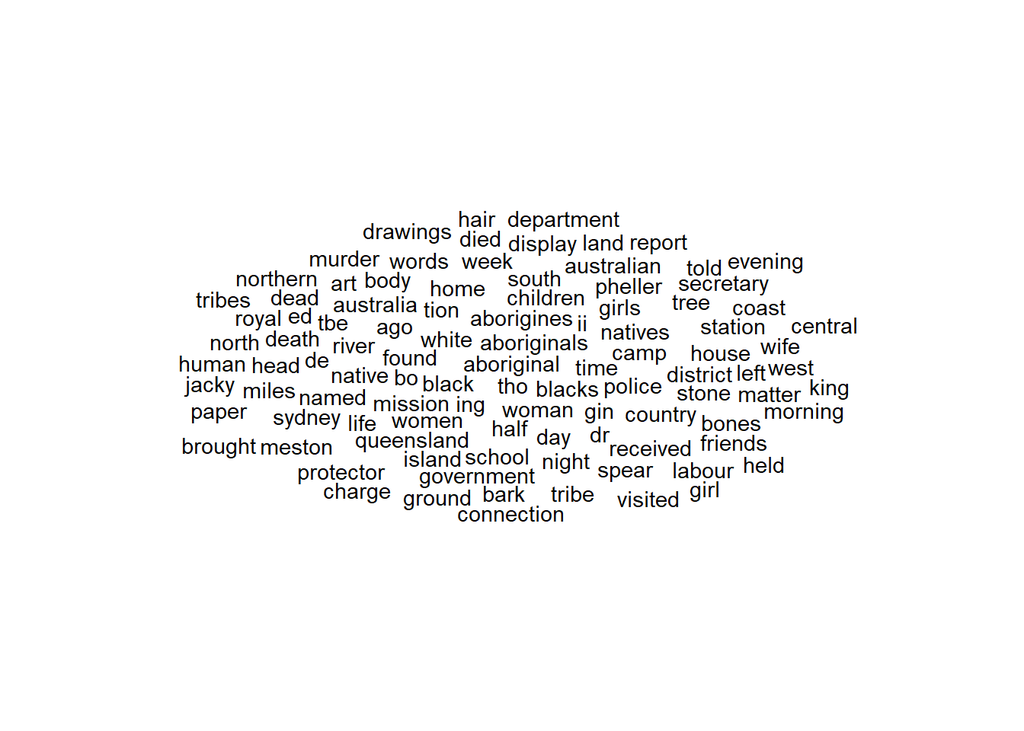

```r
Aboriginal_1900_1909_cloud <- ggplot(data = Aboriginal_1900_1909_top100, aes( label = word)) + geom_text_wordcloud() + theme_minimal()

Aboriginal_1900_1909_cloud
```

## Customize cloud

Shows the most frequent used words from the 100 articles where green is most,then yellow and last pink.

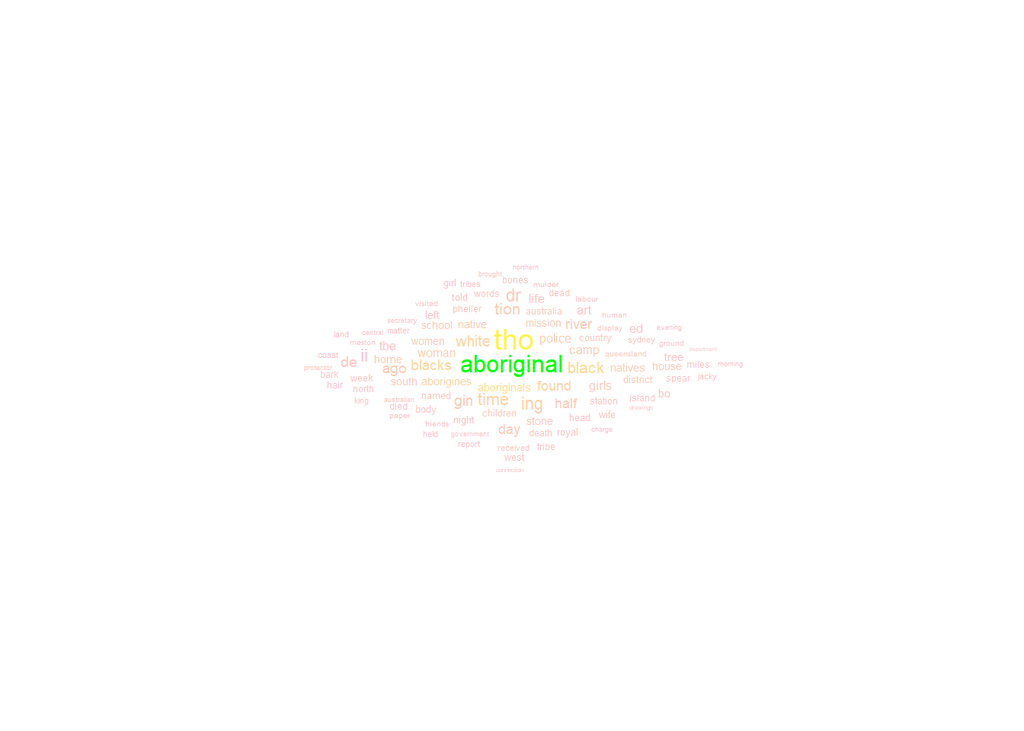

```r
ggplot(data = Aboriginal_1900_1909_top100, aes(label = word, size = n)) +
  geom_text_wordcloud_area(aes(color = n), shape = "diamond") +
  scale_size_area(max_size = 12) +
  scale_color_gradientn(colors = c("pink", "yellow", "green")) +
  theme_minimal()
```

# Sentiment analysis

## Lexicon afinn

```r
get_sentiments(lexicon = "afinn")
```

```
## # A tibble: 2,477 × 2
##    word       value
##    <chr>      <dbl>
##  1 abandon       -2
##  2 abandoned     -2
##  3 abandons      -2
##  4 abducted      -2
##  5 abduction     -2
##  6 abductions    -2
##  7 abhor         -3
##  8 abhorred      -3
##  9 abhorrent     -3
## 10 abhors        -3
## # ℹ 2,467 more rows
```

```r
afinn_pos <- get_sentiments("afinn") %>%
  filter(value %in% c(3,4,5))
```

```r
afinn_pos
```

```
## # A tibble: 222 × 2
##    word         value
##    <chr>        <dbl>
##  1 admire           3
##  2 admired          3
##  3 admires          3
##  4 admiring         3
##  5 adorable         3
##  6 adore            3
##  7 adored           3
##  8 adores           3
##  9 affection        3
## 10 affectionate     3
## # ℹ 212 more rows
```

## Lexicon bing

```r
get_sentiments(lexicon = "bing")
```

```
## # A tibble: 6,786 × 2
##    word        sentiment
##    <chr>       <chr>
##  1 2-faces     negative
##  2 abnormal    negative
##  3 abolish     negative
##  4 abominable  negative
##  5 abominably  negative
##  6 abominate   negative
##  7 abomination negative
##  8 abort       negative
##  9 aborted     negative
## 10 aborts      negative
## # ℹ 6,776 more rows
```

## Lexicon nrc

```r
get_sentiments(lexicon = "nrc")
```

```
## # A tibble: 13,872 × 2
##    word        sentiment
##    <chr>       <chr>
##  1 abacus      trust
##  2 abandon     fear
##  3 abandon     negative
##  4 abandon     sadness
##  5 abandoned   anger
##  6 abandoned   fear
##  7 abandoned   negative
##  8 abandoned   sadness
##  9 abandonment anger
## 10 abandonment fear
## # ℹ 13,862 more rows
```

## Aboriginal 1900 to 1909 afinn

Inner join connects the stopwords column(word) with the afinn column(value).

```r
Aboriginal_1900_1909_afinn <-  Aboriginal_1900_1909_stop%>%
  inner_join(get_sentiments("afinn"))
```

## Aboriginal 1900 to 1909 afinn hist

Counts the value of Aboriginal 1900 to 1909 afinn.

```r
Aboriginal_1900_1909_afinn_hist <- Aboriginal_1900_1909_afinn%>%
  count(value)
```

## Plot Aboriginal 1900 to 1909 afinn hist

The x-axis(value) is the sentiment value where negative is shown as minus and positive with no minus and n is the amount of words that has the specific sentiment value from the x-axis(value).

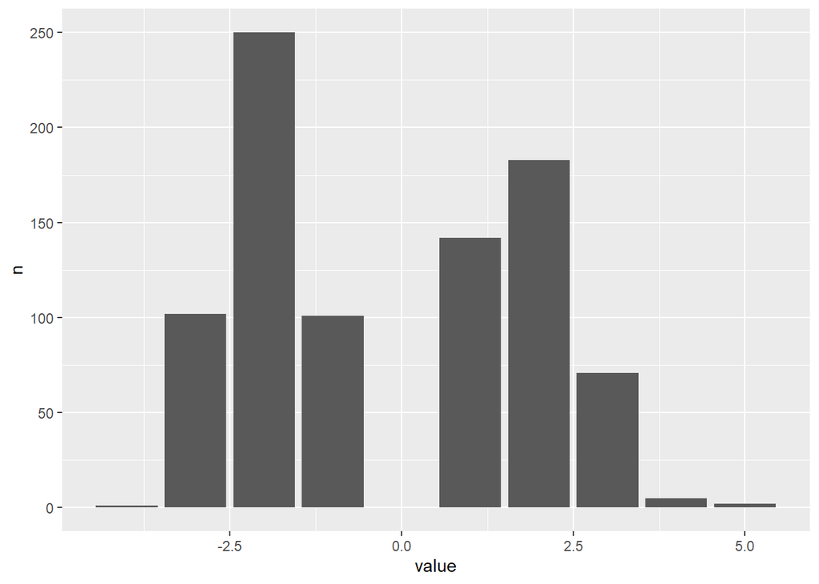

```r
ggplot(data = Aboriginal_1900_1909_afinn_hist, aes(x = value, y = n)) +
  geom_col()
```

## Aboriginal 1900 to 1909 afinn2

Here filter removes words that do not have a value on 2.

```r
Aboriginal_1900_1909_afinn2 <- Aboriginal_1900_1909_afinn %>%
  filter(value == 2)
```

## Unique 2 words score

```r
unique(Aboriginal_1900_1909_afinn2$word)
```

```
##  [1] "benefits"      "worth"         "commend"       "accomplished"
##  [5] "benefit"       "mercy"         "enjoy"         "friendly"
##  [9] "favor"         "fine"          "positively"    "advantage"
## [13] "opportunity"   "comfortable"   "true"          "determined"
## [17] "secured"       "save"          "cheering"      "swift"
## [21] "hero"          "humour"        "humorous"      "improve"
## [25] "noble"         "improved"      "progress"      "encourage"
## [29] "improvement"   "strongest"     "strong"        "clean"
## [33] "clever"        "jolly"         "heaven"        "cheerful"
## [37] "care"          "worthy"        "hail"          "healthy"
## [41] "desired"       "peace"         "intelligent"   "approved"
## [45] "carefully"     "comprehensive" "justified"     "top"
## [49] "helping"       "responsible"   "treasure"      "justice"
## [53] "honour"        "attracting"    "remarkable"    "saved"
## [57] "stout"         "appreciated"   "appeased"      "trusted"
## [61] "gained"        "success"       "freedom"       "careful"
## [65] "encouraged"    "smiled"        "dedicated"     "rich"
## [69] "dear"          "powerful"      "honest"        "attraction"
## [73] "secure"        "adventures"    "importance"    "desirable"
## [77] "hope"          "cheered"       "honoured"      "recommended"
## [81] "romance"       "approval"      "eager"         "competent"
## [85] "enlighten"     "rescue"        "hopeful"       "growth"
## [89] "sympathetic"   "strengthen"
```

## Count plot Aboriginal 1900 to 1909 afinn2 n

```r
Aboriginal_1900_1909_afinn2_n<- Aboriginal_1900_1909_afinn2%>%
  count(word, sort = TRUE) %>%
  mutate(word = fct_reorder(factor(word), n))
```

## Count and plot graph

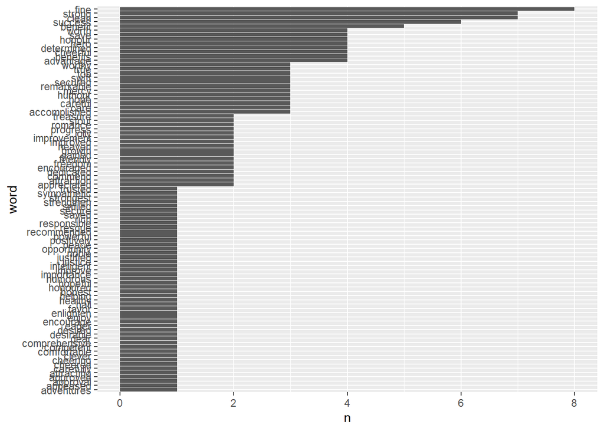

```r
ggplot(data = Aboriginal_1900_1909_afinn2_n, aes(x = word, y = n)) +
  geom_col() +
  coord_flip()
```

## Summerize sentiment

```r
Aboriginal_1900_1909_summery <- Aboriginal_1900_1909_afinn%>%
  summarise(mean_score = mean(value), median_score = median(value))
```

## Aboriginal 1900 to 1909 nrc

Inner join connects the stopwords column(word) with the nrc column(sentiment).

```r
Aboriginal_1900_1909_nrc <- Aboriginal_1900_1909_stop%>%
  inner_join(get_sentiments("nrc"))
```

## Exclude

Anti join finds all words that do not match two dataframes.

```r
Aboriginal_1900_1909_exclude <- Aboriginal_1900_1909_stop %>%
  anti_join(get_sentiments("nrc"))
```

## Count most exluded

```r
Aboriginal_1900_1909_exclude_n <-  Aboriginal_1900_1909_exclude%>%
  count(word, sort = TRUE)
```

## Show Aboriginal 1900 to 1909 exclude n head

```r
head(Aboriginal_1900_1909_exclude_n)
```

```
## # A tibble: 6 × 2
##   word            n
##   <chr>       <int>
## 1 aboriginal    185
## 2 tho            79
## 3 aboriginals    47
## 4 black          44
## 5 blacks         40
## 6 white          37
```

## Emplot Aboriginal 1900 to 1909 nrc n

The x-axis(sentiment) is the type of sentiment while the y-axis(n) is the amount of a sentiment from the x-axis.

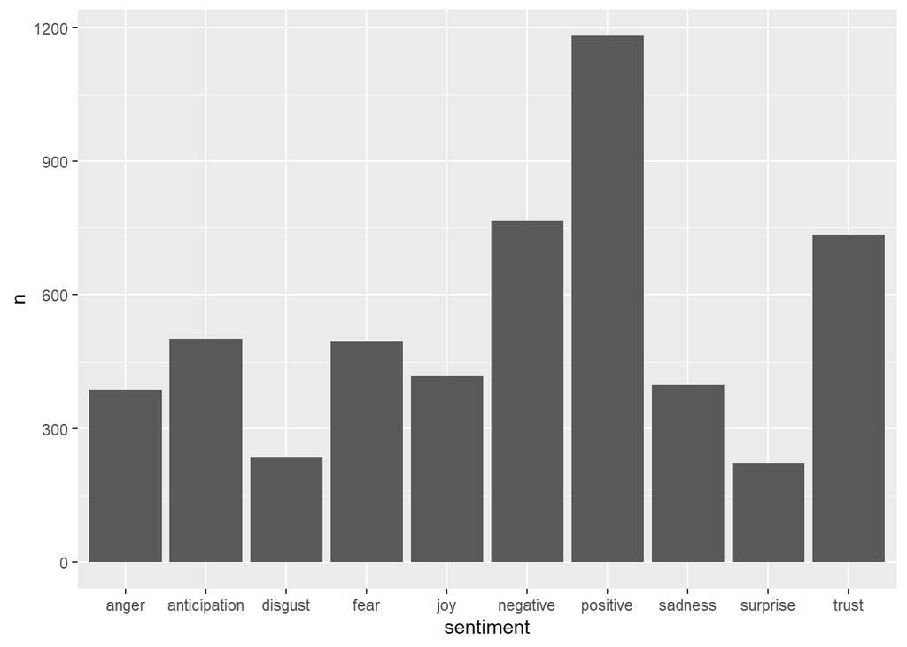

```r
Aboriginal_1900_1909_nrc_n <- Aboriginal_1900_1909_nrc %>%
  count(sentiment, sort = TRUE )

ggplot(data = Aboriginal_1900_1909_nrc_n, aes(x = sentiment, y = n)) +
  geom_col()
```

## Count sentiment and word

There are multiple graphs each divided by a sentiment and each have a x-axis which represents the amount of sentiment to a specific word from the y-axis.

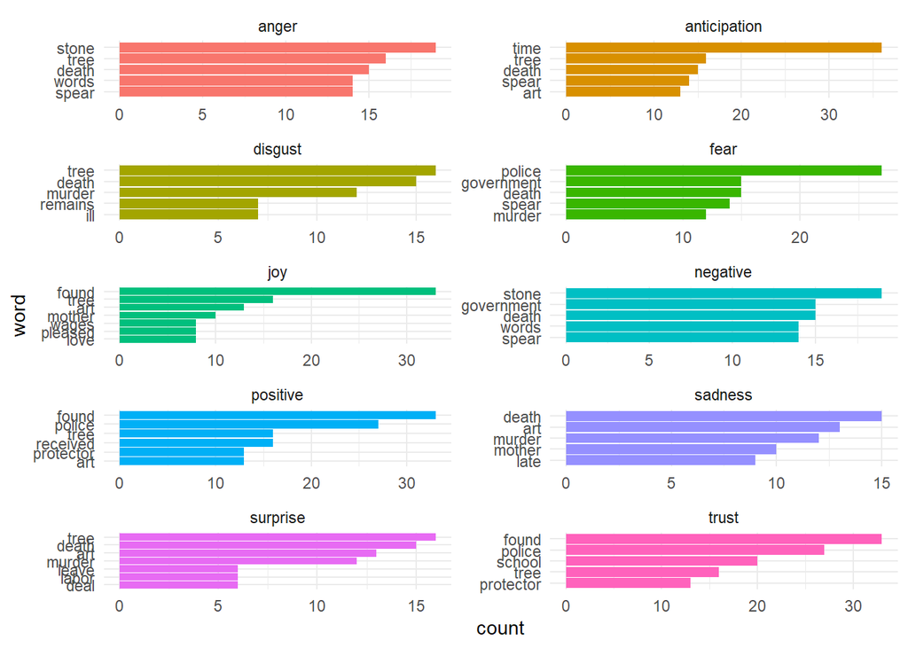

```r
Aboriginal_1900_1909_nrc_n5 <- Aboriginal_1900_1909_nrc %>%
  count(word,sentiment,sort = TRUE) %>%
  group_by(sentiment) %>%
  top_n(5) %>%
  ungroup()

Aboriginal_1900_1909_nrc_gg <- ggplot(data = Aboriginal_1900_1909_nrc_n5, aes(x = reorder(word,n), y = n, fill = sentiment)) +
  geom_col(show.legend = FALSE) +
  facet_wrap(~sentiment, ncol = 2, scales = "free") +
  coord_flip() +
  theme_minimal() +
  labs(x = "word" , y = "count")

Aboriginal_1900_1909_nrc_gg
```

## Save it

```r
ggsave(plot = Aboriginal_1900_1909_nrc_gg,
       filename = "figures/ipcc_nrc_sentiment.png",
      height = 8,
      width = 5)
```